# 3. Data Analysis

##### Análise do texto

Os casos abaixo verificarão se o algoritmo do Comprehend conseguiu detectar os sentimentos adequadamente em relação às notas. Espera-se que apareçam mais sentimentos positivos para os maiores scores e sentimentos negativos para notas mais baixas. Além disso, os principais elementos para cada score serão avaliados.

```python
sentiment_palette = {"NEGATIVE": "r", "POSITIVE": "g", "MIXED": "orange", "NEUTRAL": "m"}
```

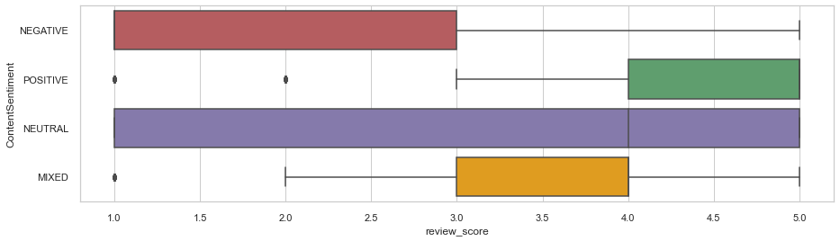

```python
plt.figure(figsize=(15,4))
ax = sns.boxplot(y='ContentSentiment', x='review_score', orient='h', data=df, palette=sentiment_palette)
plt.show()
```

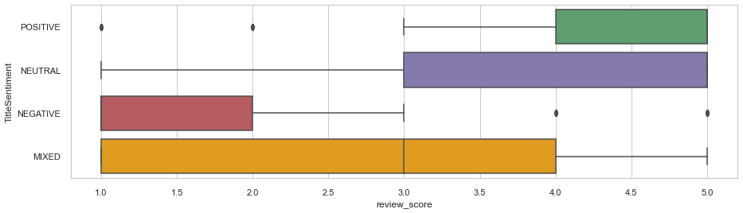

```python
plt.figure(figsize=(15,4))
ax = sns.boxplot(y='TitleSentiment', x='review_score', orient='h', data=df, palette=sentiment_palette)
plt.show()
```

```python
for score in sorted(df[df['review_score'] >= 1]['review_score'].unique()):
    values = df[(df['review_score'] == score)]['ContentKeyEntities'].dropna().str.split(',').values.tolist()
    display(score)
    display(Counter(list(chain.from_iterable(values))).most_common(20))
```

```
1.0
```

```
[('o produto', 1954),
 ('que', 1151),
 ('recebi', 994),
 ('produto', 793),
 ('me', 660),
 ('eu', 639),
 ('nada', 330),
 ('esta', 270),
 ('prazo', 226),
 ('o momento', 222),
 ('o que', 200),
 ('site', 194),
 ('um produto', 186),
 ('isso', 183),
 ('o', 182),
 ('ninguem', 172),
 ('a compra', 168),
 ('a entrega', 163),
 ('se', 159),
 ('a loja', 157)]
```

```
2.0
```

```
[('o produto', 485),
 ('que', 283),
 ('eu', 189),
 ('produto', 165),
 ('recebi', 164),
 ('me', 128),
 ('prazo', 104),
 ('a entrega', 73),
 ('esta', 66),
 ('site', 53),
 ('a loja', 52),
 ('entrega', 48),
 ('q', 45),
 ('o', 45),
 ('um produto', 44),
 ('defeito', 41),
 ('isso', 39),
 ('se', 39),
 ('a compra', 37),
 ('ele', 37)]
```

```
3.0
```

```
[('o produto', 692),
 ('que', 400),
 ('prazo', 309),
 ('eu', 260),
 ('produto', 259),
 ('recebi', 150),
 ('me', 139),
 ('a entrega', 128),
 ('isso', 92),
 ('esta', 87),
 ('tudo', 82),
 ('bom', 71),
 ('o', 65),
 ('q', 64),
 ('entrega', 63),
 ('a loja', 62),
 ('o que', 62),
 ('correios', 61),
 ('a compra', 55),
 ('site', 54)]
```

```
4.0
```

```
[('prazo', 1086),
 ('o produto', 861),
 ('produto', 600),
 ('que', 426),
 ('eu', 292),
 ('tudo', 268),
 ('a entrega', 198),
 ('entrega', 194),
 ('bom', 135),
 ('me', 114),
 ('entrega rapida', 98),
 ('a loja', 88),
 ('recebi', 88),
 ('produto bom', 87),
 ('otimo', 82),
 ('isso', 80),
 ('site', 73),
 ('q', 71),
 ('bom produto', 68),
 ('o que', 67)]
```

```
5.0
```

```
[('prazo', 4675),
 ('o produto', 2273),
 ('produto', 2140),
 ('tudo', 1007),
 ('que', 933),
 ('eu', 893),
 ('entrega', 764),
 ('otimo', 618),
 ('entrega rapida', 603),
 ('a entrega', 591),
 ('parabens', 403),
 ('otimo produto', 398),
 ('todos', 323),
 ('previsto', 291),
 ('a loja', 287),
 ('me', 253),
 ('loja', 242),
 ('a compra', 236),
 ('qualidade', 225),
 ('produto muito bom', 218)]
```

##### Comentários

As reclamações mais recorrentes (notas 1 e 2) são em relação ao produto seguido pelo prazo e defeitos. Já para as notas 4 e 5 o que maior impacta é o prazo (entrega rápida). Isto corrobora a análise feita pelo 1-way ANOVA.

##### Análise de categorias e estados

Os casos abaixo verificarão o comportamento entre os grupos de compra e os estados em relação à satisfação do cliente.

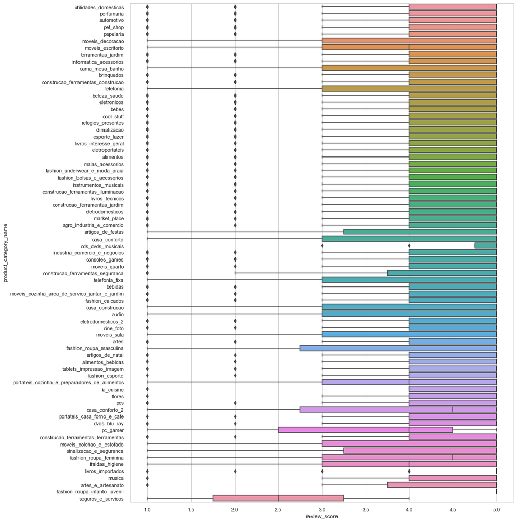

```python
plt.figure(figsize=(15,20))
ax = sns.boxplot(y='product_category_name', x='review_score', orient='h', data=df)
plt.show()
```

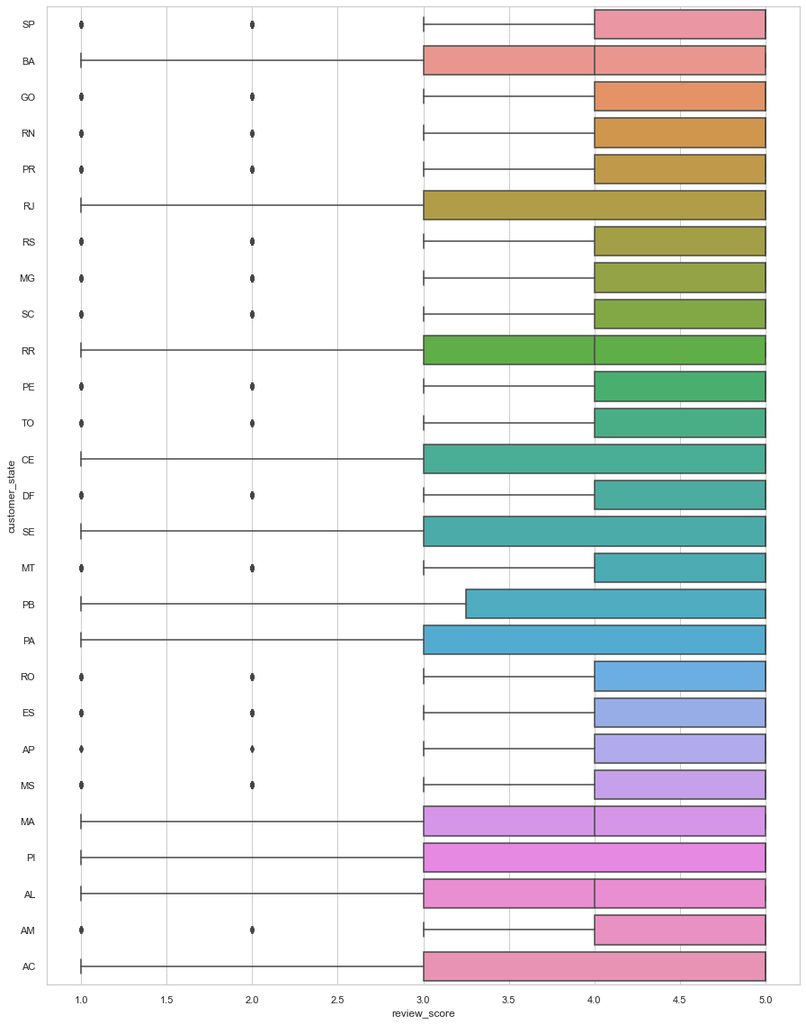

```python
plt.figure(figsize=(15,20))
ax = sns.boxplot(y='customer_state', x='review_score', orient='h', data=df)
plt.show()
```

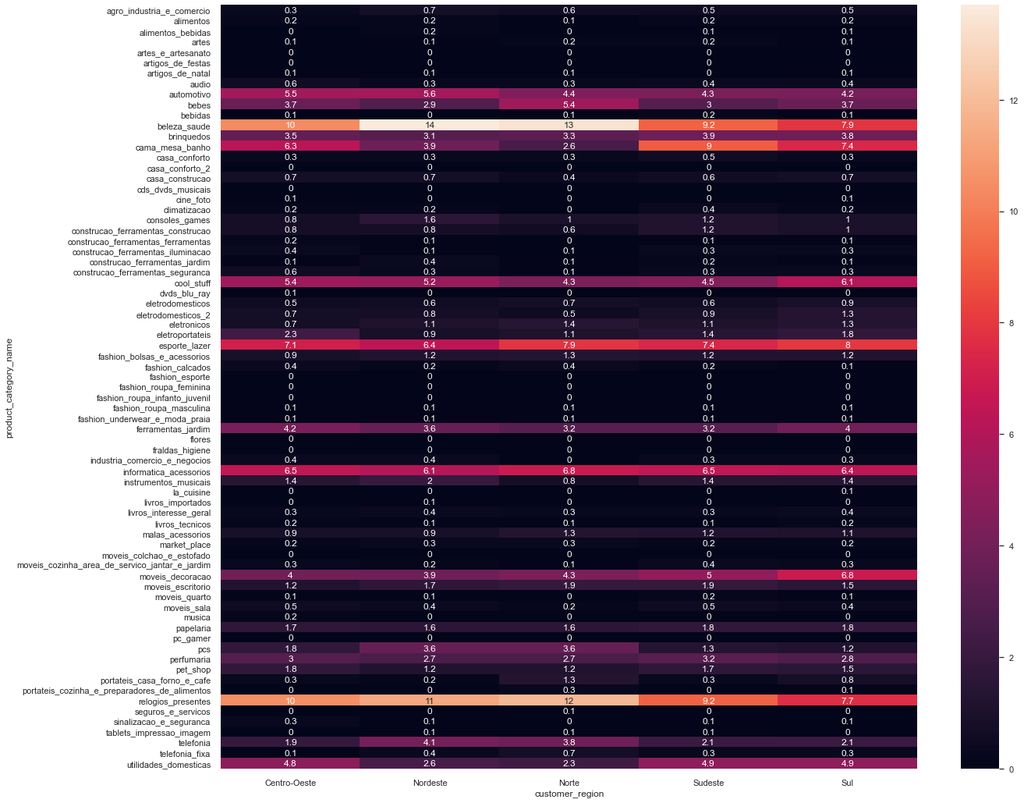

```python
# analisando a porcentagem vendida de cada produto por região
df_sold_state = pd.pivot_table(df[['customer_region', 'product_category_name', 'price', 'review_score']], \
               values='price', index=['customer_region'], columns=['product_category_name'], aggfunc=np.sum).fillna(0).T

min_max_scaler = preprocessing.MinMaxScaler()
df_sold_state = (100. * df_sold_state / df_sold_state.sum()).round(1)

plt.figure(figsize=(20,18))
ax = sns.heatmap(df_sold_state, annot=True)
plt.show()
```

##### Comentários

De forma geral, o que mais vende são produtos das categorias relogios_presentes, beleza_saude, informatica_acessorios e esporte_lazer. Na região Sul, há um equilíbrio entre esporte_lazer, beleza_saude, cama_mesa_banho, cool_stuff, informatica_acessorios e moveis_decoracao. Já no Sudeste há um equilíbrio entre relogios_presentes, cama_mesa_banho e beleza_saude. No Norte, Nordeste e Centro-Oeste há uma predominância do relogios_presentes e beleza_saude.

As compras relacionadas a seguros_e_servicos e pc_gamer possuem uma insatisfação maior. Já os compradores do Norte e Nordeste possuem também uma tendência maior à insatisfação.

```python
df_predict = df[['order_purchase_wday', 'order_delivery_estimate_wday', 'order_approval_wday', \
                 'order_approval_delivery_difference', 'review_score', 'price', 'freight_value', 'product_category_name', \
                 'seller_state', 'customer_state', 'total_paid', 'distance_seller_customer']].dropna()
df_predict = pd.get_dummies(df_predict[~df_predict['review_score'].isnull()], \
                            prefix=['product_category_name', 'seller_state', 'customer_state'])

X_train, X_test, y_train, y_test = train_test_split(df_predict.drop('review_score', axis=1), df_predict['review_score'], \
                                                    test_size=0.15, random_state=0)
```

```python
clf_lgb = LGBMClassifier(objective='multiclass', n_estimators=1000, min_child_samples=10, importance_type='gain')
clf_rf = RandomForestClassifier()
clf_ba = BaggingClassifier()

clf = VotingClassifier(estimators=[('lgb', clf_lgb), ('rf', clf_rf), ('ba', clf_ba)], voting='hard')
clf.fit(X_train, y_train)
display(f'Score: {clf.score(X_test, y_test)}')
multilabel_confusion_matrix(y_test, clf.predict(X_test))
```

```
'Score: 0.5868421052631579'
```

```
array([[[13081,   235],
        [ 1313,   191]],

       [[14310,    27],
        [  462,    21]],

       [[13528,    58],
        [ 1187,    47]],

       [[11621,   214],
        [ 2849,   136]],

       [[  617,  5589],
        [  312,  8302]]], dtype=int64)
```